# FIT3152 Data Analytics Assignment2

#### - Se Eun Park (32722303)

The following packages has been imported and utilized in this report:

- library(tree), library(e1071), library(adabag), library(randomForest), library(ROCR), library(rpart), library(neuralnet), library(caret)

My individual data, **PD** consists of 2,000 rows of data of 26 variables(attributes).

```r
rm(list = ls())
Phish <- read.csv("PhishingData.csv")
set.seed(32722303) # Your Student ID is the random seed
L <- as.data.frame(c(1:50))
L <- L[sample(nrow(L), 10, replace = FALSE),]
Phish <- Phish[(Phish$A01 %in% L),]
PD <- Phish[sample(nrow(Phish), 2000, replace = FALSE),] # sample of 2000 rows
```

### 1.

As shown in Appendix 1.0, the data structure of the PD data consists of 2000 rows and 26 variables, including integer (int) and float (num) values describing various website features. The last column, Class, indicates whether a website is phishing (1) or legitimate (0). Attributes A08, A22, and A24 are floats, whereas A03, A06, A07, A09, A10, A15, A16, A20, and Class comprise binomial values, exclusively encompassing 0 or 1.There are 417 rows with at least one NA value (Appendix 1.1).

### 2.

I have removed all the rows containing NA values to keep the analysis reliable. Although more than 20% of the websites listed in PD has missing values, I have decided to remove them rather than imputating them, as what the attributes are representing is unknown, and consequently their importance are unknown. Now, I will be using PD_clean data for my analysis.

```r
PD_clean <- na.omit(PD)
```

### 3.

Before dividing my data into training and test data, I have made the Class attribute as a factor for classification processes.

```r
PD_clean$Class <- as.factor(PD_clean$Class)

set.seed(32722303) #Student ID as random seed
train.row = sample(1:nrow(PD_clean), 0.7*nrow(PD_clean))
PD_clean.train = PD_clean[train.row,]
PD_clean.test = PD_clean[-train.row,]
```

### 4.

- Decision Tree

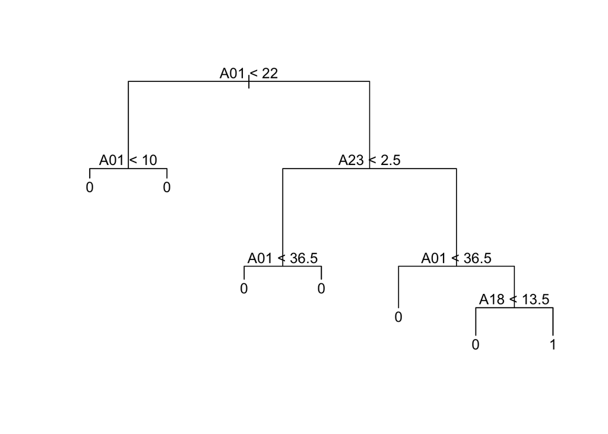

  ```r
  library(tree)
  PD_clean.tree = tree(Class ~., data = PD_clean.train)
  plot(PD_clean.tree)
  text(PD_clean.tree, pretty = 0)
  ```

- Naïve Bayes

  ```r
  library(e1071)
  PD_clean.bayes = naiveBayes(Class ~. , data = PD_clean.train)
  ```

- Bagging

  ```r
  library(adabag)
  PD_clean.bag <- bagging(Class ~. , data = PD_clean.train, mfinal=5)
  ```

- Boosting

  ```r
  PD_clean.boost <- boosting(Class ~. , data = PD_clean.train, mfinal=10)
  ```

- Random Forest

  ```r
  library(randomForest)
  PD_clean.rf <- randomForest(Class ~. , data = PD_clean.train, na.action = na.exclude)
  ```

### 5.

- Decision Tree

  Code can be found in Appendix 5.0

  ```
  ##
  ## Decision Tree Confusion
  ```

  ```
  ##                Actual_Class
  ## Predicted_Class   0   1
  ##               0 312  88
  ##               1   8  67
  ```

  ```
  ## [1] "Accuracy: 0.7979"
  ```

- Naïve Bayes

  Code can be found in Appendix 5.1

  ```
  ##
  ## Naive Bayes Confusion
  ```

  ```
  ##                Actual_Class
  ## Predicted_Class   0   1
  ##               0  13   7
  ##               1 307 148
  ```

  ```
  ## [1] "Accuracy: 0.3389"
  ```

- Bagging

  Code can be found in Appendix 5.2

  ```
  ##
  ## Bagging Confusion
  ```

  ```
  ##                Observed Class
  ## Predicted Class   0   1
  ##               0 299  73
  ##               1  21  82
  ```

  ```
  ## [1] "Accuracy: 0.8021"
  ```

- Boosting

  Code can be found in Appendix 5.3

  ```
  ##
  ## Boosting Confusion
  ```

  ```
  ##                Observed Class
  ## Predicted Class   0   1
  ##               0 291  73
  ##               1  29  82
  ```

  ```
  ## [1] "Accuracy: 0.7853"
  ```

- Random Forest

  Code can be found in Appendix 5.4

  ```
  ##
  ## Random Forest Confusion
  ```

  ```
  ##                Actual_Class
  ## Predicted_Class   0   1
  ##               0 304  71
  ##               1  16  84
  ```

  ```
  ## [1] "Accuracy: 0.8168"
  ```

### 6.

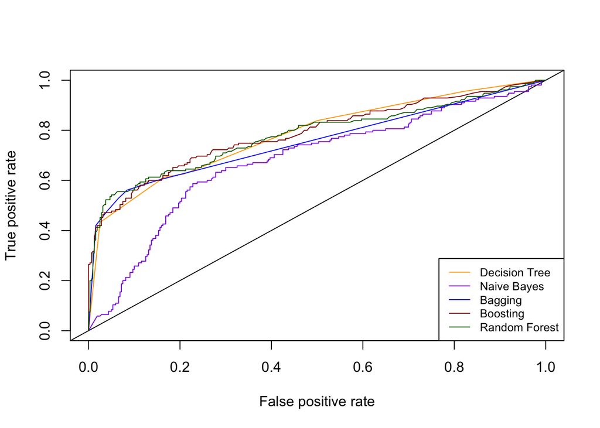

```r
library(ROCR)

# Decision Tree
PD_clean.pred.tree = predict(PD_clean.tree, PD_clean.test, type = "vector")
PD_cleanDpred <- prediction(PD_clean.pred.tree[,2], PD_clean.test$Class)
PD_cleanDperf <- performance(PD_cleanDpred,"tpr","fpr")
PD_cleanDAUC <- performance(PD_cleanDpred, "auc")@y.values[[1]]
plot(PD_cleanDperf, col = "orange")
abline(0,1)

# Naive Bayes
PD_clean.pred.bayes = predict(PD_clean.bayes, PD_clean.test, type = 'raw')
PD_cleanBpred <- prediction( PD_clean.pred.bayes[,2], PD_clean.test$Class)
PD_cleanBperf <- performance(PD_cleanBpred,"tpr","fpr")
PD_cleanBAUC <- performance(PD_cleanBpred, "auc")@y.values[[1]]
plot(PD_cleanBperf, add=TRUE, col = "blueviolet")

# Bagging
PD_cleanBagpred <- prediction(PD_cleanpred.bag$prob[,2], PD_clean.test$Class)
PD_cleanBagperf <- performance(PD_cleanBagpred,"tpr","fpr")
PD_cleanBagAUC <- performance(PD_cleanBagpred, "auc")@y.values[[1]]
plot(PD_cleanBagperf, add=TRUE, col = "blue")

# Boosting
PD_cleanBoostpred <- prediction( PD_cleanpred.boost$prob[,2], PD_clean.test$Class)
PD_cleanBoostperf <- performance(PD_cleanBoostpred,"tpr","fpr")
PD_cleanBoostAUC <- performance(PD_cleanBoostpred, "auc")@y.values[[1]]
plot(PD_cleanBoostperf, add=TRUE, col = "darkred")

# Random Forest
PD_cleanpred.rf <- predict(PD_clean.rf, PD_clean.test, type="prob")
PD_cleanFpred <- prediction( PD_cleanpred.rf[,2], PD_clean.test$Class)
PD_cleanFperf <- performance(PD_cleanFpred,"tpr","fpr")
PD_cleanFAUC <- performance(PD_cleanFpred, "auc")@y.values[[1]]
plot(PD_cleanFperf, add=TRUE, col = "darkgreen")

legend("bottomright",
       legend = c("Decision Tree", "Naive Bayes", "Bagging", "Boosting", "Random Forest"),
       col = c("orange", "blueviolet", "blue", "darkred", "darkgreen"),
       lty = 1, cex = 0.8)
```

### 7.

Code can be found in Appendix 7.0

```
##      Classifier  Accuracy       AUC
## 1 Decision Tree 0.7978947 0.7820161
## 2   Naive Bayes 0.3389474 0.6801109
## 3       Bagging 0.8021053 0.7553931
## 4      Boosting 0.7852632 0.7867641
## 5 Random Forest 0.8168421 0.7797883
```

As shown in the table above, Random Forest has the highest accuracy (0.8168), followed by Bagging (0.8021).

Boosting has the highest AUC (0.7868), but Random Forest (0.7798) and Decision Tree(0.7820) are close behind.

Therefore, there isn’t a single “best” classifier across all metrics.

### 8.

Code can be found in Appendix 8.0

```
##
## #Decision Tree Attribute Importance
```

```
##
## Classification tree:
## tree(formula = Class ~ ., data = PD_clean.train)
## Variables actually used in tree construction:
## [1] "A01" "A23" "A18"
## Number of terminal nodes:  7
## Residual mean deviance:  0.9126 = 1005 / 1101
## Misclassification error rate: 0.2049 = 227 / 1108
```

```
##
## #Bagging Attribute Importance
```

```
##       A01       A02       A03       A04       A05       A06       A07       A08
## 44.162147  0.000000  0.000000  0.000000  0.000000  0.000000  0.000000  3.274761
##       A09       A10       A11       A12       A13       A14       A15       A16
##  0.000000  0.000000  0.000000  0.000000  0.000000  0.000000  0.000000  0.000000
##       A17       A18       A19       A20       A21       A22       A23       A24
##  0.000000 17.488505  0.000000  0.000000  0.000000  6.113411 25.726773  3.234403
##       A25
##  0.000000
```

```
##
## #Boosting Attribute Importance
```

```
##        A01        A02        A03        A04        A05        A06        A07
## 22.4330524  0.2480491  0.0000000  0.9240018  0.0000000  0.9705160  0.0000000
##        A08        A09        A10        A11        A12        A13        A14
## 10.1206965  0.0000000  0.0000000  0.0000000  3.4694353  0.0000000  1.1400515
##        A15        A16        A17        A18        A19        A20        A21
##  0.2004786  0.5074970  4.3841192 11.8362512  0.9053873  0.4990780  0.0000000
##        A22        A23        A24        A25
## 14.2056373 21.5330299  6.6227189  0.0000000
```

```
##
## #Random Forest Attribute Importance
```

```
##     MeanDecreaseGini
## A01      96.17269342
## A02       4.72695786
## A03       0.00000000
## A04       7.01676850
## A05       0.11934952
## A06       7.78728740
## A07       0.05038559
## A08      32.85384717
## A09       3.02809406
## A10       2.10521170
## A11       1.05650052
## A12      23.77318341
## A13       0.05744416
## A14      17.76452896
## A15       5.28877691
## A16       3.89004164
## A17      11.19799024
## A18      66.28534776
## A19       5.37813155
## A20       7.65223620
## A21       1.35570035
## A22      59.98153447
## A23      77.41809909
## A24      29.54940658
## A25       0.05977534
```

Decision Tree: Variables actually used in tree construction: “A01”, “A23”, “A18”

Bagging: The most important variables are “A01”, “A18”, and “A23”.

Random Forest: The most important variables are “A01”, “A18”, “A22”, and “A23”.

In summary, the most important variables across all models are consistently “A01”, “A18”, and “A23”. “A22” is also frequently highlighted as important, especially in the Boosting and Random Forest models.

Variables that consistently show low importance values across all models could potentially be omitted, such as “A02”, “A03”, “A05”, “A06”, “A07”, “A09”, “A10”, “A11”, “A13”, “A14”, “A15”, “A16”, “A17”, “A19”, “A20”, “A21”, and “A25”, which have either zero or very low importance values in multiple models. They will be less influential in predicting the Class variable and may have minimal impact on model performance.

### 9.

All the codes for the following diagrams and outputs can be found in Appendix 9.0

The decision tree model that is created is as follows:

[figure not shown]

With the test data, the performance of the model is as follows:

```
##          Actual
## Predicted   0   1
##         0 312  88
##         1   8  67
```

```
## Accuracy: 0.7978947
```

```r
# Generate predicted probabilities for the ROC curve
predicted_probabilities <- predict(tree_model, PD_clean.test, type = "prob")[, 2]
# Calculate the ROC curve
pred <- prediction(predicted_probabilities, actual_labels)
perf <- performance(pred, "tpr", "fpr")
# Calculate the AUC
auc <- performance(pred, "auc")
auc_value <- as.numeric(auc@y.values)
cat("AUC:", auc_value, "\n")
```

```
## AUC: 0.771371
```

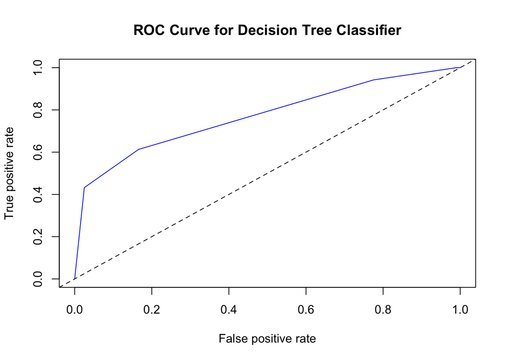

```
##           Classifier  Accuracy       AUC
## 1 Decision Tree (Q9) 0.7978947 0.7713710
## 2 Decision Tree (Q4) 0.7978947 0.7820161
## 3        Naive Bayes 0.3389474 0.6801109
## 4            Bagging 0.8021053 0.7553931
## 5           Boosting 0.7852632 0.7867641
## 6      Random Forest 0.8168421 0.7797883
```

```r
#Plot the ROC curve
plot(perf, col = "blue", main = "ROC Curve for Decision Tree Classifier")
abline(a = 0, b = 1, lty = 2)
```

For the decision tree that I have built with the attributes that I have selected, it gives the same accuracy as the decision tree in Q4. However, there is a slight difference in AUC. This decision tree has a slightly lower AUC, but overall considered to be a good model.

### 10.

The following is the code and result of the best tree-based classifier that I have created.

```r
library(caret)
set.seed(9999)
train_control <- trainControl(method = "cv", number = 10)
# Define grid of hyperparameters to search over
tune_grid <- expand.grid(mtry = c(2, 4, 6, 8, 10))
# Train Random Forest model with cross-validation
rf_model <- train(Class ~ .,
                  data = PD_clean.train,
                  method = "rf",
                  trControl = train_control,
                  tuneGrid = tune_grid)
# Print cross-validation results
print(rf_model)
```

```
## Random Forest
##
## 1108 samples
##   25 predictor
##    2 classes: '0', '1'
##
## No pre-processing
## Resampling: Cross-Validated (10 fold)
## Summary of sample sizes: 997, 997, 997, 997, 997, 997, ...
## Resampling results across tuning parameters:
##
##   mtry  Accuracy   Kappa
##    2    0.7906388  0.5020106
##    4    0.8051024  0.5534354
##    6    0.8023833  0.5484395
##    8    0.7978870  0.5404536
##   10    0.7961016  0.5381332
##
## Accuracy was used to select the optimal model using the largest value.
## The final value used for the model was mtry = 4.
```

```r
# Get best Random Forest model from cross-validation
best_rf_model <- rf_model$finalModel

# Evaluate model performance on test data
rf_predictions <- predict(best_rf_model, newdata = PD_clean.test)
rf_confusion_matrix <- confusionMatrix(rf_predictions, PD_clean.test$Class)
print(rf_confusion_matrix)
```

```
## Confusion Matrix and Statistics
##
##           Reference
## Prediction   0   1
##          0 303  71
##          1  17  84
##
##                Accuracy : 0.8147
##                  95% CI : (0.7768, 0.8487)
##     No Information Rate : 0.6737
##     P-Value [Acc > NIR] : 4.228e-12
##
##                   Kappa : 0.537
##
##  Mcnemar's Test P-Value : 1.606e-08
##
##             Sensitivity : 0.9469
##             Specificity : 0.5419
##          Pos Pred Value : 0.8102
##          Neg Pred Value : 0.8317
##              Prevalence : 0.6737
##          Detection Rate : 0.6379
##    Detection Prevalence : 0.7874
##       Balanced Accuracy : 0.7444
##
##        'Positive' Class : 0
##
```

```r
# Calculate probabilities
rf_probabilities <- predict(best_rf_model, newdata = PD_clean.test, type = "prob")
# Create prediction object
rf_pred <- prediction(rf_probabilities[, 2], PD_clean.test$Class)
# Calculate performance measures
rf_perf <- performance(rf_pred, "tpr", "fpr")
rf_auc <- performance(rf_pred, "auc")
rf_auc_value <- rf_auc@y.values[[1]]
# Print AUC
print(paste("AUC:", auc_value))
```

```
## [1] "AUC: 0.771370967741935"
```

I have selected to improve the Random Forest model back in Q4, as it had the highest accuracy and also a fairly high AUC among the other classifiers.

From the Random Forest model, I have implemented 10-fold cross-validation, I have also done hyperparameter tuning, the identification of the optimal number of variables considered at each split. The model actually uses all available attributes, but identifies the most important ones along the training process.

As a result, the accuracy of the model showed up to be 0.8147, which is almost the same as the previous model, but AUC improved to 0.7875, making the model the classifier model with the greatest AUC.

Comparison can be found below:

```
##            Classifier  Accuracy       AUC
## 1 Random Forest (Q10) 0.8147368 0.7874597
## 2  Random Forest (Q4) 0.8168421 0.7797883
## 3  Decision Tree (Q9) 0.7978947 0.7713710
## 4  Decision Tree (Q4) 0.7978947 0.7820161
## 5    Naive Bayes (Q4) 0.3389474 0.6801109
## 6        Bagging (Q4) 0.8021053 0.7553931
## 7       Boosting (Q4) 0.7852632 0.7867641
```

### 11.

To implement the Artificial Neural Network classifier, I have done pre-processing of making a new clean data before splitting them into training and test data, and also implemented normalizations, using scale() as normalization helps in faster convergence and better performance.

**I have selected attributes A01, A18, A22, A23,** based on their importance identified in previous analyses in Q8.

```r
# Load necessary libraries
library(neuralnet)
library(caret)
library(ROCR)

PD_clean <- na.omit(PD)

# Split the data into training and test sets
train_indices <- sample(1:nrow(PD_clean), 0.8 * nrow(PD_clean))
PD_clean.train <- PD_clean[train_indices, ]
PD_clean.test <- PD_clean[-train_indices, ]

# Normalize the feature columns in the training and test sets
selected_features <- c("A01", "A18", "A22", "A23")
PD_clean.train[selected_features] <- scale(PD_clean.train[selected_features])
PD_clean.test[selected_features] <- scale(PD_clean.test[selected_features])

# Train the neural network
PD_clean.nn <- neuralnet(Class ~ A01 + A18 + A22 + A23,
                         data = PD_clean.train,
                         hidden = 3)

# Predict probabilities
PD_clean.pred <- compute(PD_clean.nn, PD_clean.test[selected_features])$net.result

# Convert probabilities to binary predictions based on threshold of 0.5
binary_predictions <- ifelse(PD_clean.pred > 0.5, 1, 0)

# Confusion matrix
confusion_matrix <- table(observed = PD_clean.test$Class, predicted = binary_predictions)
print(confusion_matrix)
```

```
##         predicted
## observed   0   1
##        0 181  18
##        1  56  62
```

```r
# Convert confusion matrix to numeric matrix for calculation
confusion_matrix <- as.matrix(confusion_matrix)

# Calculate accuracy
ann_accuracy <- sum(diag(confusion_matrix)) / sum(confusion_matrix)
print(paste("Accuracy:", round(ann_accuracy, 4)))
```

```
## [1] "Accuracy: 0.7666"
```

```r
# Calculate AUC
pred_obj <- ROCR::prediction(PD_clean.pred, PD_clean.test$Class)
perf <- performance(pred_obj, "tpr", "fpr")
ann_auc <- performance(pred_obj, "auc")@y.values[[1]]
print(paste("AUC:", round(ann_auc, 4)))
```

```
## [1] "AUC: 0.7964"
```

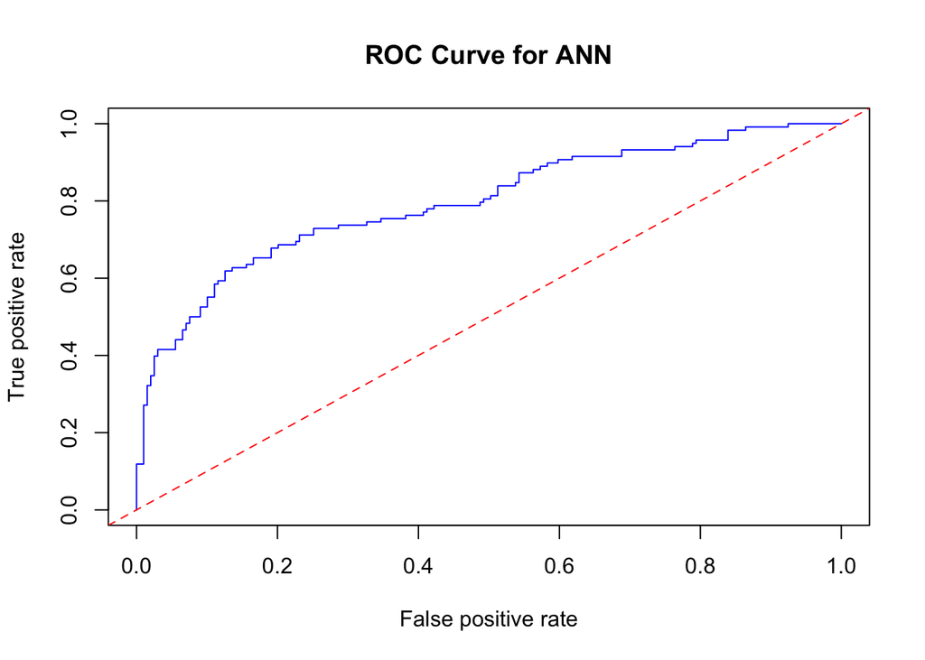

```r
# Plot ROC curve
plot(perf, main = "ROC Curve for ANN", col = "blue")
abline(0, 1, col = "red", lty = 2)
```

In performance wise, the ANN model has an accuracy of 0.7666 and AUC of 0.7963, which is considered to be good, as it has the highest AUC among all other classifiers.

```r
accuracy_value <- rf_confusion_matrix$overall['Accuracy']
comparison <- data.frame(
  Classifier = c("Artificial Neural Network","Random Forest (Q10)", "Random Forest (Q4)","Decision Tree (Q9)", "Decision Tree (Q4)", "Naive Bayes (Q4)", "Bagging (Q4)", "Boosting (Q4)"),
  Accuracy = c(ann_accuracy,accuracy_value,rf_accuracy, accuracy, tree_accuracy, bayes_accuracy, bag_accuracy, boost_accuracy ),
  AUC = c(ann_auc,rf_auc_value, PD_cleanFAUC,auc_value, PD_cleanDAUC, PD_cleanBAUC, PD_cleanBagAUC, PD_cleanBoostAUC))

print(comparison)
```

```
##                  Classifier  Accuracy       AUC
## 1 Artificial Neural Network 0.7665615 0.7963972
## 2       Random Forest (Q10) 0.8147368 0.7874597
## 3        Random Forest (Q4) 0.8168421 0.7797883
## 4        Decision Tree (Q9) 0.7978947 0.7713710
## 5        Decision Tree (Q4) 0.7978947 0.7820161
## 6          Naive Bayes (Q4) 0.3389474 0.6801109
## 7              Bagging (Q4) 0.8021053 0.7553931
## 8             Boosting (Q4) 0.7852632 0.7867641
```

### 12.

I will be implementing Support Vector Machine (SVM) using the **`e1071`** package.

Link to package details: https://cran.r-project.org/web/packages/e1071/e1071.pdf

SVM finds the hyperplane that best separates the data into classes. The radial basis function (RBF) kernel, used in this implementation, maps the input space into a higher-dimensional space, allowing the SVM to handle non-linearly separable data.

Similarly, I have done pre-processing of making a new clean data before splitting them into training and test data, and I have selected attributes A01, A18, A22, A23, based on their importance identified in previous analyses in Q8.

```r
# Load necessary libraries
library(e1071)
library(ROCR)

PD_clean <- na.omit(PD)

PD_clean$Class <- as.factor(PD_clean$Class)

# Split the data into training and test sets
train_indices <- sample(1:nrow(PD_clean), 0.8 * nrow(PD_clean))
PD_clean.train <- PD_clean[train_indices, ]
PD_clean.test <- PD_clean[-train_indices, ]

# Train the Support Vector Machine model
svm_model <- svm(Class ~ A01 + A18 + A22 + A23,
                 data = PD_clean.train,
                 kernel = "radial",
                 gamma = 0.1,
                 cost = 10)

# Make predictions on the test set
svm_pred <- predict(svm_model, PD_clean.test)

# Calculate accuracy
svm_accuracy <- mean(svm_pred == PD_clean.test$Class)
print(paste("Accuracy:", round(svm_accuracy, 4)))
```

```
## [1] "Accuracy: 0.7697"
```

```r
# Create confusion matrix
confusion_matrix <- table(observed = PD_clean.test$Class, predicted = svm_pred)
print(confusion_matrix)
```

```
##         predicted
## observed   0   1
##        0 205  12
##        1  61  39
```

```r
# Create prediction object for ROC curve
pred_obj <- ROCR::prediction(as.numeric(svm_pred), as.numeric(PD_clean.test$Class))

# Calculate ROC curve and AUC
perf <- performance(pred_obj, "tpr", "fpr")
svm_auc <- performance(pred_obj, "auc")@y.values[[1]]
print(paste("AUC:", round(svm_auc, 4)))
```

```
## [1] "AUC: 0.6674"
```

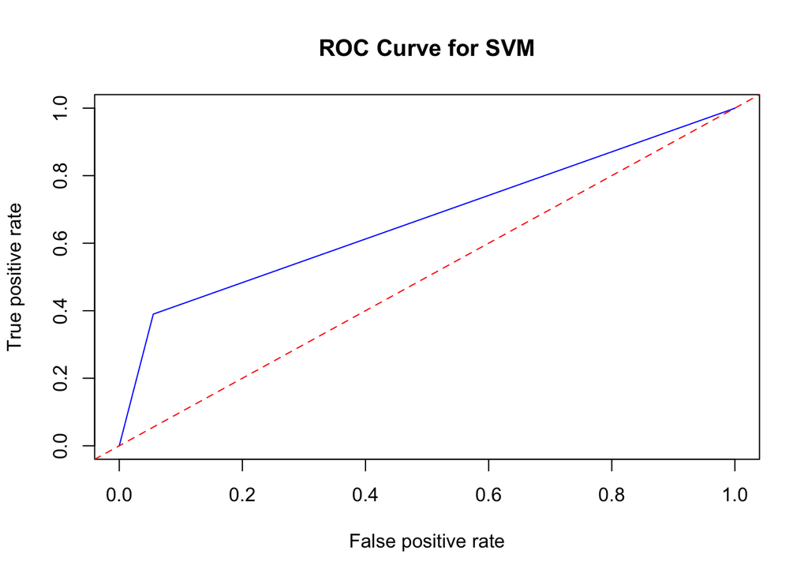

```r
# Plot ROC curve
plot(perf, main = "ROC Curve for SVM", col = "blue")
abline(0, 1, col = "red", lty = 2)
```

In the model, it trains the classifier using the radial basis function (RBF) kernel with specific hyperparameters (gamma = 0.1 and cost = 10).

In performance wise, the SVM model has an accuracy of 0.7697 and AUC of 0.6674, which is considered not too bad.

However, when it comes to the comparison with other classifiers, the SVM model built is not the best:

```r
accuracy_value <- rf_confusion_matrix$overall['Accuracy']
comparison <- data.frame(
  Classifier = c("Support Vector Machine","Artificial Neural Network","Random Forest (Q10)", "Random Forest (Q4)","Decision Tree (Q9)", "Decision Tree (Q4)", "Naive Bayes (Q4)", "Bagging (Q4)", "Boosting (Q4)"),
  Accuracy = c(svm_accuracy,ann_accuracy,accuracy_value,rf_accuracy, accuracy, tree_accuracy, bayes_accuracy, bag_accuracy, boost_accuracy ),
  AUC = c(svm_auc,ann_auc,rf_auc_value, PD_cleanFAUC,auc_value, PD_cleanDAUC, PD_cleanBAUC, PD_cleanBagAUC, PD_cleanBoostAUC))

print(comparison)
```

```
##                  Classifier  Accuracy       AUC
## 1    Support Vector Machine 0.7697161 0.6673502
## 2 Artificial Neural Network 0.7665615 0.7963972
## 3       Random Forest (Q10) 0.8147368 0.7874597
## 4        Random Forest (Q4) 0.8168421 0.7797883
## 5        Decision Tree (Q9) 0.7978947 0.7713710
## 6        Decision Tree (Q4) 0.7978947 0.7820161
## 7          Naive Bayes (Q4) 0.3389474 0.6801109
## 8              Bagging (Q4) 0.8021053 0.7553931
## 9             Boosting (Q4) 0.7852632 0.7867641
```

### Appendix

1.0

```r
str(PD)
```

```
## 'data.frame':    2000 obs. of  26 variables:
##  $ A01  : int  27 17 8 47 50 50 6 28 17 13 ...
##  $ A02  : int  0 0 0 0 0 0 0 0 0 5 ...
##  $ A03  : int  0 0 0 0 0 0 0 0 0 0 ...
##  $ A04  : int  3 3 3 2 3 2 3 2 2 3 ...
##  $ A05  : int  0 0 0 0 0 0 0 0 0 0 ...
##  $ A06  : int  0 0 0 0 1 0 0 0 0 0 ...
##  $ A07  : int  0 0 0 0 0 0 0 0 0 0 ...
##  $ A08  : num  1 1 0.714 1 1 ...
##  $ A09  : int  0 0 0 0 0 0 0 0 0 0 ...
##  $ A10  : int  0 0 0 0 0 0 0 1 0 0 ...
##  $ A11  : int  0 0 0 0 0 0 0 0 0 0 ...
##  $ A12  : int  232 232 504 210 232 648 232 310 569 232 ...
##  $ A13  : int  0 0 0 0 0 0 0 0 0 0 ...
##  $ A14  : int  0 0 0 0 NA 0 0 0 1 0 ...
##  $ A15  : int  0 0 0 0 0 0 0 1 0 0 ...
##  $ A16  : int  0 0 0 0 0 0 0 0 0 0 ...
##  $ A17  : int  1 1 1 1 1 2 1 1 1 1 ...
##  $ A18  : int  32 5 5 7 25 53 8 14 54 106 ...
##  $ A19  : int  0 0 0 0 0 0 0 0 0 0 ...
##  $ A20  : int  1 0 0 0 0 1 0 0 0 0 ...
##  $ A21  : int  0 0 0 0 0 0 0 0 0 0 ...
##  $ A22  : num  0.0681 0.0601 0.0613 0.0593 0.0545 ...
##  $ A23  : int  107 0 100 0 1 13 100 100 107 118 ...
##  $ A24  : num  0.522907 0.522907 0.079963 0.000186 0.522907 ...
##  $ A25  : num  0 0 0 0 0 0 0 0 0 0 ...
##  $ Class: int  1 1 0 1 1 1 0 1 0 1 ...
```

1.1

```r
# Count the number of rows with any NA values
na_row_count <- sum(apply(PD, 1, function(row) any(is.na(row))))
print(na_row_count)
```

```
## [1] 417
```

1.2

```r
# Count the number of phishing sites (1)
phishing_count <- sum(PD$Class== 1)
# Count the number of legitimate sites (0)
legitimate_count <- sum(PD$Class == 0)

# Calculate the proportion
proportion <- phishing_count / legitimate_count
print(proportion)
```

```
## [1] 0.5515904
```

1.3

```r
# Calculate sd and variance for each attribute
attribute_sd <- sprintf("%.4f", apply(PD[, -ncol(PD)], 2, sd, na.rm = TRUE))
attribute_var <- sprintf("%.4f", apply(PD[, -ncol(PD)], 2, var, na.rm = TRUE))

attribute_stats <- data.frame(Attribute = names(PD)[1:(ncol(PD)-1)], sd = attribute_sd, var = attribute_var)
print(attribute_stats)
```

```
##    Attribute       sd        var
## 1        A01  16.2631   264.4887
## 2        A02   1.0917     1.1919
## 3        A03   0.0449     0.0020
## 4        A04   0.5931     0.3518
## 5        A05   0.4795     0.2300
## 6        A06   0.3471     0.1205
## 7        A07   0.0502     0.0025
## 8        A08   0.2184     0.0477
## 9        A09   0.1685     0.0284
## 10       A10   0.1885     0.0355
## 11       A11   0.6119     0.3744
## 12       A12 146.0580 21332.9438
## 13       A13   0.5168     0.2671
## 14       A14   0.3408     0.1161
## 15       A15   0.3215     0.1034
## 16       A16   0.2128     0.0453
## 17       A17   0.6017     0.3621
## 18       A18  80.3310  6453.0742
## 19       A19   0.3131     0.0980
## 20       A20   0.4360     0.1901
## 21       A21   0.1857     0.0345
## 22       A22   0.0105     0.0001
## 23       A23  60.5075  3661.1565
## 24       A24   0.2518     0.0634
## 25       A25   0.0049     0.0000
```

5.0

```r
PD_clean.predtree = predict(PD_clean.tree, PD_clean.test, type = "class")
tree_confusion= table(Predicted_Class = PD_clean.predtree, Actual_Class = PD_clean.test$Class)
cat("\nDecision Tree Confusion\n")
```

```
##
## Decision Tree Confusion
```

```r
print(tree_confusion)
```

```
##                Actual_Class
## Predicted_Class   0   1
##               0 209  61
##               1   8  39
```

```r
# Accuracy
tree_accuracy <- sum(diag(tree_confusion)) / sum(tree_confusion)
print(paste("Accuracy:", round(tree_accuracy, 4)))
```

```
## [1] "Accuracy: 0.7823"
```

7.0

```r
comparison <- data.frame(
  Classifier = c("Decision Tree", "Naive Bayes", "Bagging", "Boosting", "Random Forest"),
  Accuracy = c(tree_accuracy, bayes_accuracy, bag_accuracy, boost_accuracy, rf_accuracy),
  AUC = c(PD_cleanDAUC, PD_cleanBAUC, PD_cleanBagAUC, PD_cleanBoostAUC, PD_cleanFAUC))

print(comparison)
```

```
##      Classifier  Accuracy       AUC
## 1 Decision Tree 0.7823344 0.7820161
## 2   Naive Bayes 0.3389474 0.6801109
## 3       Bagging 0.8021053 0.7553931
## 4      Boosting 0.7852632 0.7867641
## 5 Random Forest 0.8168421 0.7797883
```

8.0

```r
# Attribute importance
cat("\n#Decision Tree Attribute Importance\n")
```

```
##
## #Decision Tree Attribute Importance
```

```r
print(summary(PD_clean.tree))
```

```
##
## Classification tree:
## tree(formula = Class ~ ., data = PD_clean.train)
## Variables actually used in tree construction:
## [1] "A01" "A23" "A18"
## Number of terminal nodes:  7
## Residual mean deviance:  0.9126 = 1005 / 1101
## Misclassification error rate: 0.2049 = 227 / 1108
```

```r
cat("\n#Bagging Attribute Importance\n")
```

```
##
## #Bagging Attribute Importance
```

```r
print(PD_clean.bag$importance)
```

```
##       A01       A02       A03       A04       A05       A06       A07       A08
## 44.162147  0.000000  0.000000  0.000000  0.000000  0.000000  0.000000  3.274761
##       A09       A10       A11       A12       A13       A14       A15       A16
##  0.000000  0.000000  0.000000  0.000000  0.000000  0.000000  0.000000  0.000000
##       A17       A18       A19       A20       A21       A22       A23       A24
##  0.000000 17.488505  0.000000  0.000000  0.000000  6.113411 25.726773  3.234403
##       A25
##  0.000000
```

```r
cat("\n#Boosting Attribute Importance\n")
```

```
##
## #Boosting Attribute Importance
```

```r
print(PD_clean.boost$importance)
```

```
##        A01        A02        A03        A04        A05        A06        A07
## 22.4330524  0.2480491  0.0000000  0.9240018  0.0000000  0.9705160  0.0000000
##        A08        A09        A10        A11        A12        A13        A14
## 10.1206965  0.0000000  0.0000000  0.0000000  3.4694353  0.0000000  1.1400515
##        A15        A16        A17        A18        A19        A20        A21
##  0.2004786  0.5074970  4.3841192 11.8362512  0.9053873  0.4990780  0.0000000
##        A22        A23        A24        A25
## 14.2056373 21.5330299  6.6227189  0.0000000
```

```r
cat("\n#Random Forest Attribute Importance\n")
```

```
##
## #Random Forest Attribute Importance
```

```r
print(PD_clean.rf$importance)
```

```
##     MeanDecreaseGini
## A01      96.17269342
## A02       4.72695786
## A03       0.00000000
## A04       7.01676850
## A05       0.11934952
## A06       7.78728740
## A07       0.05038559
## A08      32.85384717
## A09       3.02809406
## A10       2.10521170
## A11       1.05650052
## A12      23.77318341
## A13       0.05744416
## A14      17.76452896
## A15       5.28877691
## A16       3.89004164
## A17      11.19799024
## A18      66.28534776
## A19       5.37813155
## A20       7.65223620
## A21       1.35570035
## A22      59.98153447
## A23      77.41809909
## A24      29.54940658
## A25       0.05977534
```

9.0

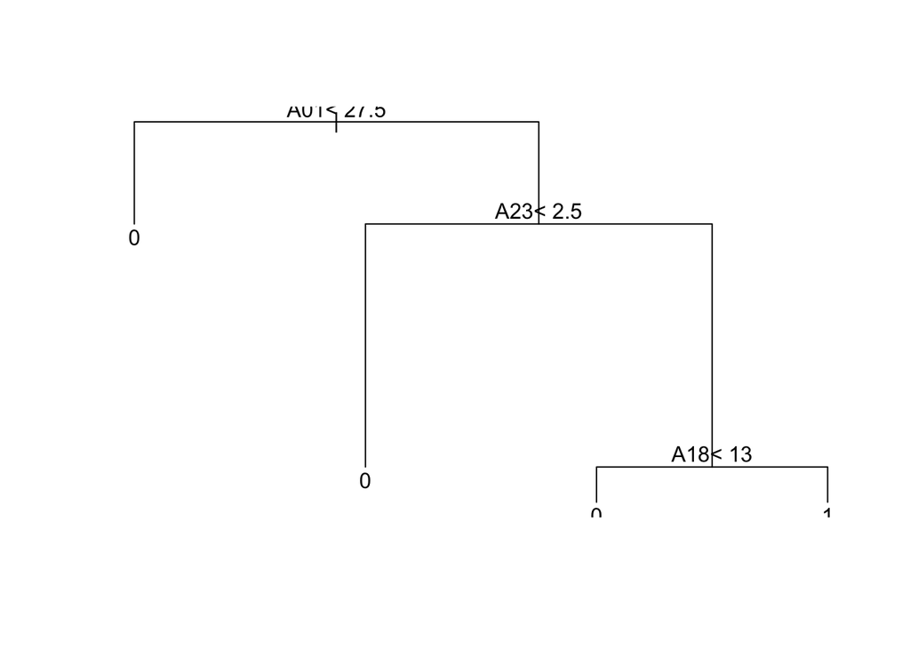

```r
library(rpart)

# Fit the decision tree model using the training data
tree_model <- rpart(Class ~ A01+A18+A23, data = PD_clean.train, method = "class")

# Plot the decision tree
plot(tree_model)
text(tree_model, pretty = 1)
```

```r
# Predict the class labels for the test data
predicted_labels <- predict(tree_model, PD_clean.test, type = "class")

# Assuming PD_clean.test$Class contains the actual labels
actual_labels <- PD_clean.test$Class

# Calculate the confusion matrix, accuracy, and other metrics
confusion_matrix <- table(Predicted = predicted_labels, Actual = actual_labels)
print(confusion_matrix)
```

```
##          Actual
## Predicted   0   1
##         0 195  52
##         1  22  48
```

```r
accuracy <- sum(predicted_labels == actual_labels) / length(actual_labels)
cat("Accuracy:", accuracy, "\n")
```

```
## Accuracy: 0.7665615
```